# (Flights Dataset Exploration)

## by (Mai Ezzat Farghaly Abdellatif)

## Preliminary Wrangling

> This dataset reports flights in the United States, including carriers, arrival and departure delays, and reasons for delays, from 2004 to 2020.

```python
# import all packages and set plots to be embedded inline
import numpy as np
import pandas as pd
import matplotlib.pyplot as plt
import seaborn as sb

%matplotlib inline
```

> Load in your dataset and describe its properties through the questions below. Try and motivate your exploration goals through this section.

```python
df = pd.read_csv("airline_delay_causes.csv")
df.head()
```

|  | year | month | carrier | carrier_name | airport | airport_name | arr_flights | arr_del15 | carrier_ct | weather_ct | ... | security_ct | late_aircraft_ct | arr_cancelled | arr_diverted | arr_delay | carrier_delay | weather_delay | nas_delay | security_delay | late_aircraft_delay |
| --- | --- | --- | --- | --- | --- | --- | --- | --- | --- | --- | --- | --- | --- | --- | --- | --- | --- | --- | --- | --- | --- |
| 0 | 2004 | 1 | DL | Delta Air Lines Inc. | PBI | West Palm Beach/Palm Beach, FL: Palm Beach Int... | 650.0 | 126.0 | 21.06 | 6.44 | ... | 1.0 | 45.92 | 4.0 | 0.0 | 5425.0 | 881.0 | 397.0 | 2016.0 | 15.0 | 2116.0 |
| 1 | 2004 | 1 | DL | Delta Air Lines Inc. | PDX | Portland, OR: Portland International | 314.0 | 61.0 | 14.09 | 2.61 | ... | 0.0 | 10.05 | 30.0 | 3.0 | 2801.0 | 478.0 | 239.0 | 1365.0 | 0.0 | 719.0 |
| 2 | 2004 | 1 | DL | Delta Air Lines Inc. | PHL | Philadelphia, PA: Philadelphia International | 513.0 | 97.0 | 27.60 | 0.42 | ... | 0.0 | 17.12 | 15.0 | 0.0 | 4261.0 | 1150.0 | 16.0 | 2286.0 | 0.0 | 809.0 |
| 3 | 2004 | 1 | DL | Delta Air Lines Inc. | PHX | Phoenix, AZ: Phoenix Sky Harbor International | 334.0 | 78.0 | 20.14 | 2.02 | ... | 0.0 | 16.45 | 3.0 | 1.0 | 3400.0 | 1159.0 | 166.0 | 1295.0 | 0.0 | 780.0 |
| 4 | 2004 | 1 | DL | Delta Air Lines Inc. | PIT | Pittsburgh, PA: Pittsburgh International | 217.0 | 47.0 | 8.08 | 0.44 | ... | 0.0 | 16.59 | 4.0 | 1.0 | 1737.0 | 350.0 | 28.0 | 522.0 | 0.0 | 837.0 |

5 rows × 21 columns

```python
df.info()
```

```
<class 'pandas.core.frame.DataFrame'>
RangeIndex: 283906 entries, 0 to 283905
Data columns (total 21 columns):
 #   Column               Non-Null Count   Dtype
---  ------               --------------   -----
 0   year                 283906 non-null  int64
 1    month               283906 non-null  int64
 2   carrier              283906 non-null  object
 3   carrier_name         283906 non-null  object
 4   airport              283906 non-null  object
 5   airport_name         283906 non-null  object
 6   arr_flights          283450 non-null  float64
 7   arr_del15            283224 non-null  float64
 8   carrier_ct           283450 non-null  float64
 9    weather_ct          283450 non-null  float64
 10  nas_ct               283450 non-null  float64
 11  security_ct          283450 non-null  float64
 12  late_aircraft_ct     283450 non-null  float64
 13  arr_cancelled        283450 non-null  float64
 14  arr_diverted         283450 non-null  float64
 15   arr_delay           283450 non-null  float64
 16   carrier_delay       283450 non-null  float64
 17  weather_delay        283450 non-null  float64
 18  nas_delay            283450 non-null  float64
 19  security_delay       283450 non-null  float64
 20  late_aircraft_delay  283450 non-null  float64
dtypes: float64(15), int64(2), object(4)
memory usage: 45.5+ MB
```

```python
df.isnull().sum()
```

```
year                     0
 month                   0
carrier                  0
carrier_name             0
airport                  0
airport_name             0
arr_flights            456
arr_del15              682
carrier_ct             456
 weather_ct            456
nas_ct                 456
security_ct            456
late_aircraft_ct       456
arr_cancelled          456
arr_diverted           456
 arr_delay             456
 carrier_delay         456
weather_delay          456
nas_delay              456
security_delay         456
late_aircraft_delay    456
dtype: int64
```

```python
df.shape
```

```
(283906, 21)
```

```python
df.duplicated().sum()
```

```
0
```

> Drop Missing Values

```python
df = df.dropna()
```

```python
df.isnull().sum()
```

```
year                   0
 month                 0
carrier                0
carrier_name           0
airport                0
airport_name           0
arr_flights            0
arr_del15              0
carrier_ct             0
 weather_ct            0
nas_ct                 0
security_ct            0
late_aircraft_ct       0
arr_cancelled          0
arr_diverted           0
 arr_delay             0
 carrier_delay         0
weather_delay          0
nas_delay              0
security_delay         0
late_aircraft_delay    0
dtype: int64
```

```python
df.shape
```

```
(283224, 21)
```

```python
df.columns
```

```
Index(['year', ' month', 'carrier', 'carrier_name', 'airport', 'airport_name',
       'arr_flights', 'arr_del15', 'carrier_ct', ' weather_ct', 'nas_ct',
       'security_ct', 'late_aircraft_ct', 'arr_cancelled', 'arr_diverted',
       ' arr_delay', ' carrier_delay', 'weather_delay', 'nas_delay',
       'security_delay', 'late_aircraft_delay'],
      dtype='object')
```

> Change the type of columns from float to integers

```python
column_names = ['arr_flights', 'arr_del15', 'carrier_ct', ' weather_ct', 'nas_ct',
                'security_ct', 'late_aircraft_ct', 'arr_cancelled', 'arr_diverted',
                ' arr_delay', ' carrier_delay', 'weather_delay', 'nas_delay',
                'security_delay', 'late_aircraft_delay']
for column_name in column_names :
    df[column_name] = df[column_name].astype(int)
```

```python
df.info()
```

```
<class 'pandas.core.frame.DataFrame'>
Int64Index: 283224 entries, 0 to 283905
Data columns (total 21 columns):
 #   Column               Non-Null Count   Dtype
---  ------               --------------   -----
 0   year                 283224 non-null  int64
 1    month               283224 non-null  int64
 2   carrier              283224 non-null  object
 3   carrier_name         283224 non-null  object
 4   airport              283224 non-null  object
 5   airport_name         283224 non-null  object
 6   arr_flights          283224 non-null  int32
 7   arr_del15            283224 non-null  int32
 8   carrier_ct           283224 non-null  int32
 9    weather_ct          283224 non-null  int32
 10  nas_ct               283224 non-null  int32
 11  security_ct          283224 non-null  int32
 12  late_aircraft_ct     283224 non-null  int32
 13  arr_cancelled        283224 non-null  int32
 14  arr_diverted         283224 non-null  int32
 15   arr_delay           283224 non-null  int32
 16   carrier_delay       283224 non-null  int32
 17  weather_delay        283224 non-null  int32
 18  nas_delay            283224 non-null  int32
 19  security_delay       283224 non-null  int32
 20  late_aircraft_delay  283224 non-null  int32
dtypes: int32(15), int64(2), object(4)
memory usage: 31.3+ MB
```

```python
df.head()
```

|  | year | month | carrier | carrier_name | airport | airport_name | arr_flights | arr_del15 | carrier_ct | weather_ct | ... | security_ct | late_aircraft_ct | arr_cancelled | arr_diverted | arr_delay | carrier_delay | weather_delay | nas_delay | security_delay | late_aircraft_delay |
| --- | --- | --- | --- | --- | --- | --- | --- | --- | --- | --- | --- | --- | --- | --- | --- | --- | --- | --- | --- | --- | --- |
| 0 | 2004 | 1 | DL | Delta Air Lines Inc. | PBI | West Palm Beach/Palm Beach, FL: Palm Beach Int... | 650 | 126 | 21 | 6 | ... | 1 | 45 | 4 | 0 | 5425 | 881 | 397 | 2016 | 15 | 2116 |
| 1 | 2004 | 1 | DL | Delta Air Lines Inc. | PDX | Portland, OR: Portland International | 314 | 61 | 14 | 2 | ... | 0 | 10 | 30 | 3 | 2801 | 478 | 239 | 1365 | 0 | 719 |
| 2 | 2004 | 1 | DL | Delta Air Lines Inc. | PHL | Philadelphia, PA: Philadelphia International | 513 | 97 | 27 | 0 | ... | 0 | 17 | 15 | 0 | 4261 | 1150 | 16 | 2286 | 0 | 809 |
| 3 | 2004 | 1 | DL | Delta Air Lines Inc. | PHX | Phoenix, AZ: Phoenix Sky Harbor International | 334 | 78 | 20 | 2 | ... | 0 | 16 | 3 | 1 | 3400 | 1159 | 166 | 1295 | 0 | 780 |
| 4 | 2004 | 1 | DL | Delta Air Lines Inc. | PIT | Pittsburgh, PA: Pittsburgh International | 217 | 47 | 8 | 0 | ... | 0 | 16 | 4 | 1 | 1737 | 350 | 28 | 522 | 0 | 837 |

5 rows × 21 columns

> Split the city name from the airport name

```python
df[["city_name", "airport_name_2"]] = df["airport_name"].str.split(":", expand = True)
df.head()
```

|  | year | month | carrier | carrier_name | airport | airport_name | arr_flights | arr_del15 | carrier_ct | weather_ct | ... | arr_cancelled | arr_diverted | arr_delay | carrier_delay | weather_delay | nas_delay | security_delay | late_aircraft_delay | city_name | airport_name_2 |
| --- | --- | --- | --- | --- | --- | --- | --- | --- | --- | --- | --- | --- | --- | --- | --- | --- | --- | --- | --- | --- | --- |
| 0 | 2004 | 1 | DL | Delta Air Lines Inc. | PBI | West Palm Beach/Palm Beach, FL: Palm Beach Int... | 650 | 126 | 21 | 6 | ... | 4 | 0 | 5425 | 881 | 397 | 2016 | 15 | 2116 | West Palm Beach/Palm Beach, FL | Palm Beach International |
| 1 | 2004 | 1 | DL | Delta Air Lines Inc. | PDX | Portland, OR: Portland International | 314 | 61 | 14 | 2 | ... | 30 | 3 | 2801 | 478 | 239 | 1365 | 0 | 719 | Portland, OR | Portland International |
| 2 | 2004 | 1 | DL | Delta Air Lines Inc. | PHL | Philadelphia, PA: Philadelphia International | 513 | 97 | 27 | 0 | ... | 15 | 0 | 4261 | 1150 | 16 | 2286 | 0 | 809 | Philadelphia, PA | Philadelphia International |
| 3 | 2004 | 1 | DL | Delta Air Lines Inc. | PHX | Phoenix, AZ: Phoenix Sky Harbor International | 334 | 78 | 20 | 2 | ... | 3 | 1 | 3400 | 1159 | 166 | 1295 | 0 | 780 | Phoenix, AZ | Phoenix Sky Harbor International |
| 4 | 2004 | 1 | DL | Delta Air Lines Inc. | PIT | Pittsburgh, PA: Pittsburgh International | 217 | 47 | 8 | 0 | ... | 4 | 1 | 1737 | 350 | 28 | 522 | 0 | 837 | Pittsburgh, PA | Pittsburgh International |

5 rows × 23 columns

> Rename the columns names

```python
df.columns
```

```
Index(['year', ' month', 'carrier', 'carrier_name', 'airport', 'airport_name',
       'arr_flights', 'arr_del15', 'carrier_ct', ' weather_ct', 'nas_ct',
       'security_ct', 'late_aircraft_ct', 'arr_cancelled', 'arr_diverted',
       ' arr_delay', ' carrier_delay', 'weather_delay', 'nas_delay',
       'security_delay', 'late_aircraft_delay', 'city_name', 'airport_name_2'],
      dtype='object')
```

```python
df.rename(columns = {' month':"month",
                     'arr_flights':'arr_flights_on_time',
                     'arr_del15': 'arr_del15_count',
                     'carrier_ct': 'carrier_count',
                     ' weather_ct': 'weather_count',
                     'nas_ct':'nas_count',
                     'security_ct': 'security_count',
                     'late_aircraft_ct': 'late_aircraft_count',
                     'arr_cancelled': 'arr_cancelled_count',
                     'arr_diverted':'arr_diverted_count',
                     ' arr_delay': 'total_arr_delay_min',
                     ' carrier_delay': 'carrier_delay_min',
                     'weather_delay': 'weather_delay_min',
                     'nas_delay':'nas_delay_min',
                     'security_delay': 'security_delay_min',
                     'late_aircraft_delay':'late_aircraft_delay_min'}, inplace = True)
```

```python
df.columns
```

```
Index(['year', 'month', 'carrier', 'carrier_name', 'airport', 'airport_name',
       'arr_flights_on_time', 'arr_del15_count', 'carrier_count',
       'weather_count', 'nas_count', 'security_count', 'late_aircraft_count',
       'arr_cancelled_count', 'arr_diverted_count', 'total_arr_delay_min',
       'carrier_delay_min', 'weather_delay_min', 'nas_delay_min',
       'security_delay_min', 'late_aircraft_delay_min', 'city_name',
       'airport_name_2'],
      dtype='object')
```

### What is the structure of your dataset?

> It contains 283906 rows and 21 columns.

### What is/are the main feature(s) of interest in your dataset?

> There are many reasons for delays of the flights.

### What features in the dataset do you think will help support your investigation into your feature(s) of interest?

> To get the percentage of each type of delay.

## Univariate Exploration

> In this section, investigate distributions of individual variables. If you see unusual points or outliers, take a deeper look to clean things up and prepare yourself to look at relationships between variables.

### Number Of Flights Arrived On Time All Over the Years

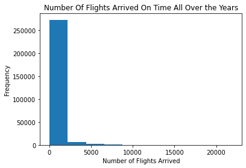

```python
plt.hist(data = df, x = "arr_flights_on_time")
plt.xlabel("Number of Flights Arrived")
plt.ylabel("Frequency")
plt.title("Number Of Flights Arrived On Time All Over the Years");
```

> After showing a histogram for the number of flights arrived on time all over the years, it seems we need to do scaling on the bins width.

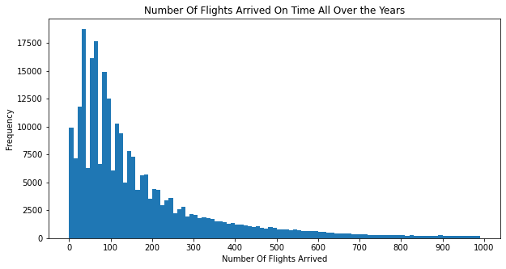

```python
plt.figure(figsize = [10, 5])
bins = range(0, 1000, 10)
plt.hist(data = df, x = "arr_flights_on_time", bins = bins)
ticks = [0, 100, 200, 300, 400, 500, 600, 700, 800, 900, 1000]
plt.xticks(ticks, ticks)
plt.xlabel("Number Of Flights Arrived")
plt.ylabel("Frequency")
plt.title("Number Of Flights Arrived On Time All Over the Years");
```

```python
df.arr_flights_on_time.describe()
```

```
count    283224.000000
mean        386.908800
std        1037.335744
min           1.000000
25%          60.000000
50%         122.000000
75%         277.000000
max       21977.000000
Name: arr_flights_on_time, dtype: float64
```

> After the scalling, the graph shows the frequency of the number of flights arrived on time.

### Number Of Flights Arrived After 15 Minutes All Over The Years

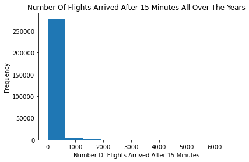

```python
plt.hist(data = df, x = "arr_del15_count")
plt.xlabel("Number Of Flights Arrived After 15 Minutes")
plt.ylabel("Frequency")
plt.title("Number Of Flights Arrived After 15 Minutes All Over The Years");
```

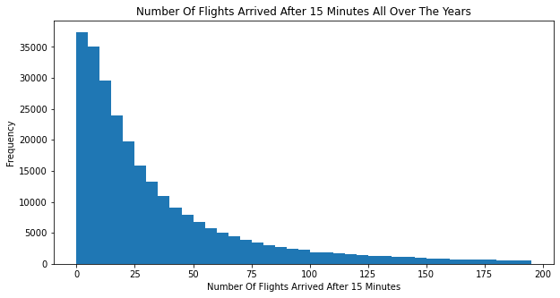

```python
plt.figure(figsize = [10, 5])
bins = range(0, 200, 5)
plt.hist(data = df, x = "arr_del15_count", bins = bins)
plt.xlabel("Number Of Flights Arrived After 15 Minutes")
plt.ylabel("Frequency")
plt.title("Number Of Flights Arrived After 15 Minutes All Over The Years");
```

> Here we can see the frequency of the number of flights arrived after 15 minutes of the scedualed time of arrival

### Number Of Flights Delayed Because Of Carrier Issue All Over The Years

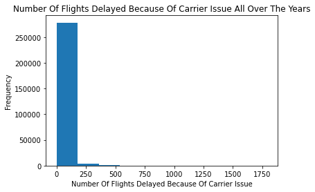

```python
plt.hist(data = df, x = "carrier_count")
plt.xlabel("Number Of Flights Delayed Because Of Carrier Issue")
plt.ylabel("Frequency")
plt.title("Number Of Flights Delayed Because Of Carrier Issue All Over The Years");
```

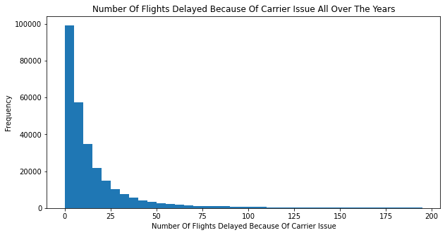

```python
plt.figure(figsize = [10, 5])
bins = range(0, 200, 5)
plt.hist(data = df, x = "carrier_count", bins = bins)
plt.xlabel("Number Of Flights Delayed Because Of Carrier Issue")
plt.ylabel("Frequency")
plt.title("Number Of Flights Delayed Because Of Carrier Issue All Over The Years");
```

> The Figure shows the frequency of the Flights delayed because of the air carrier

### Number Of Flights Delayed Because Of Weather Issue All Over The Years

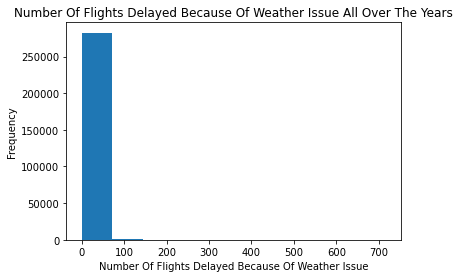

```python
plt.hist(data = df, x = "weather_count")
plt.xlabel("Number Of Flights Delayed Because Of Weather Issue")
plt.ylabel("Frequency")
plt.title("Number Of Flights Delayed Because Of Weather Issue All Over The Years");
```

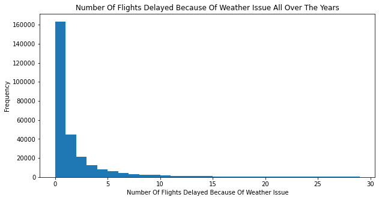

```python
plt.figure(figsize = [10, 5])
bins = range(0, 30, 1)
plt.hist(data = df, x = "weather_count", bins = bins)
plt.xlabel("Number Of Flights Delayed Because Of Weather Issue")
plt.ylabel("Frequency")
plt.title("Number Of Flights Delayed Because Of Weather Issue All Over The Years");
```

> The Figure shows the frequency of the Flights delayed because of the weather

### Number Of Flights Delayed Because Of National Aviation System(NAS) Issue All Over The Years

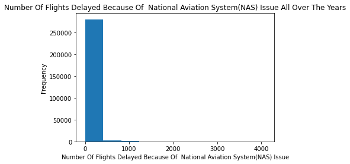

```python
plt.hist(data = df, x = "nas_count")
plt.xlabel("Number Of Flights Delayed Because Of  National Aviation System(NAS) Issue")
plt.ylabel("Frequency")
plt.title("Number Of Flights Delayed Because Of  National Aviation System(NAS) Issue All Over The Years");
```

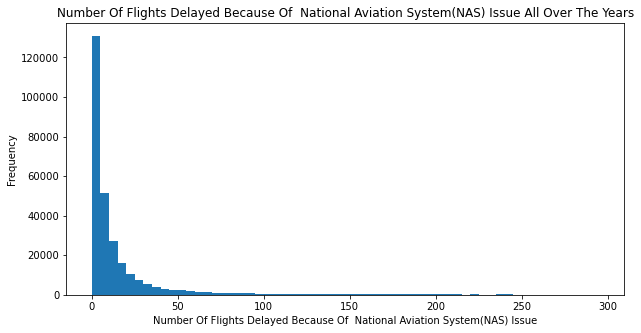

```python
plt.figure(figsize = [10, 5])
bins = range(0, 300, 5)
plt.hist(data = df, x = "nas_count", bins = bins)
plt.xlabel("Number Of Flights Delayed Because Of  National Aviation System(NAS) Issue")
plt.ylabel("Frequency")
plt.title("Number Of Flights Delayed Because Of  National Aviation System(NAS) Issue All Over The Years");
```

> The Figure shows the frequency of the Flights delayed because of the national aviation system

### Discuss the distribution(s) of your variable(s) of interest. Were there any unusual points? Did you need to perform any transformations?

> The graphs show right skewed distribution. And needed some scalling to wide the range of the ditribution

## Bivariate Exploration

> In this section, investigate relationships between pairs of variables in your data. Make sure the variables that you cover here have been introduced in some fashion in the previous section (univariate exploration).

### Number Of Flights Arrived On Time Per Year

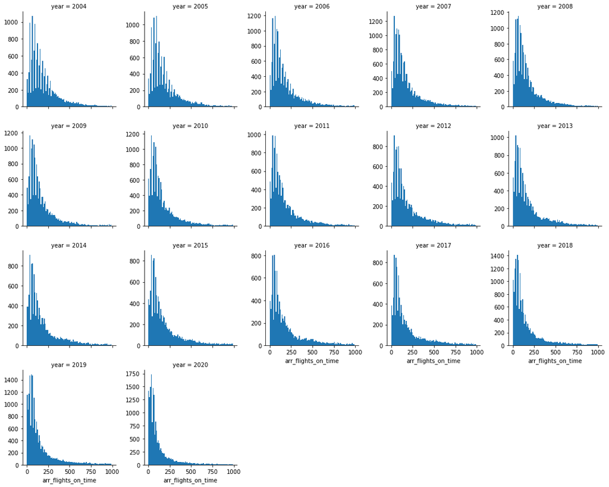

```python
g = sb.FacetGrid(data = df, col = 'year', col_wrap=5, sharey=False)
bins = range(0, 1000, 10)
g.map(plt.hist, "arr_flights_on_time", bins = bins);
```

> The Figure shows the frequency of the number of flights arrived on time in each year

### Number Of Flights Arrived After 15 Minutes Per Year

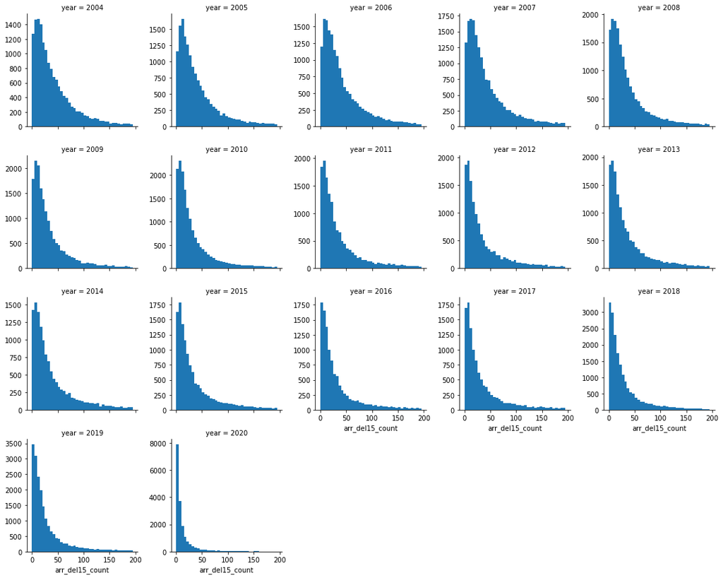

```python
g = sb.FacetGrid(data = df, col = 'year', col_wrap=5, sharey=False)
bins = range(0, 200, 5)
g.map(plt.hist, "arr_del15_count", bins = bins);
```

> The Figure shows the frequency of the number of flights arrived after 15 minutes of the schedualed time in each year

### Number Of Flights Delayed Because Of Carrier Issue Per Year

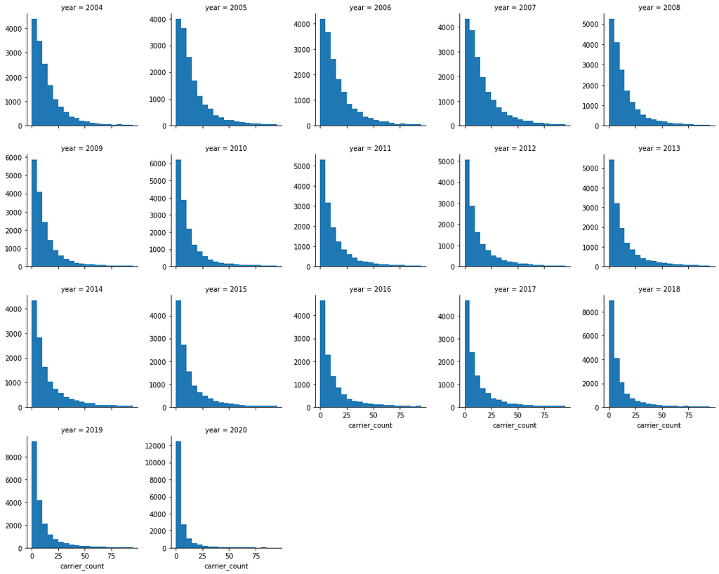

```python
g = sb.FacetGrid(data = df, col = 'year', col_wrap=5, sharey=False)
bins = range(0, 100, 5)
g.map(plt.hist, "carrier_count", bins = bins);
```

> The Figure shows the frequency of the number of flights delayed because of the air carrier in each year

### Number Of Flights Delayed Because Of Weather Issue Per Year

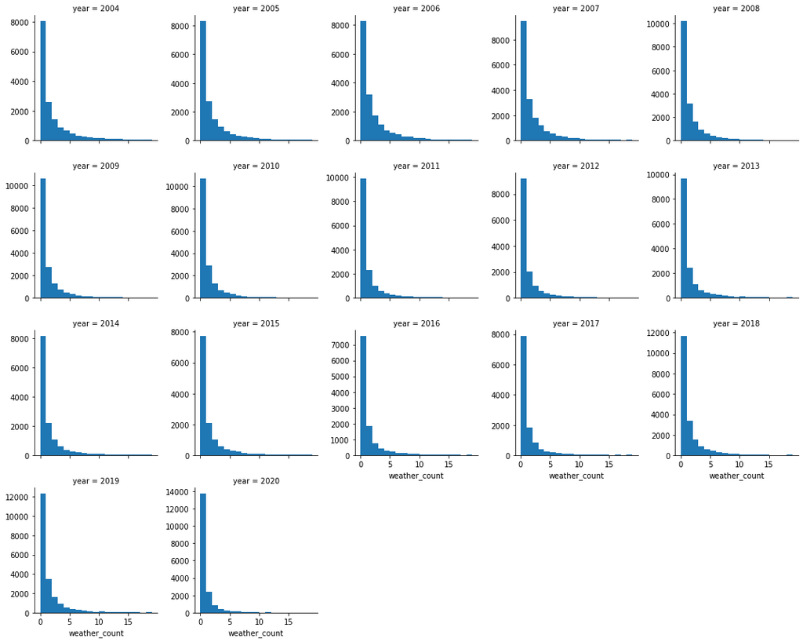

```python
g = sb.FacetGrid(data = df, col = 'year', col_wrap=5, sharey=False)
bins = range(0, 20, 1)
g.map(plt.hist, "weather_count", bins = bins);
```

> The Figure shows the frequency of the number of flights delayed because of the weather in each year

### Number Of Flights Delayed Because Of National Aviation System(NAS) Issue Per Year

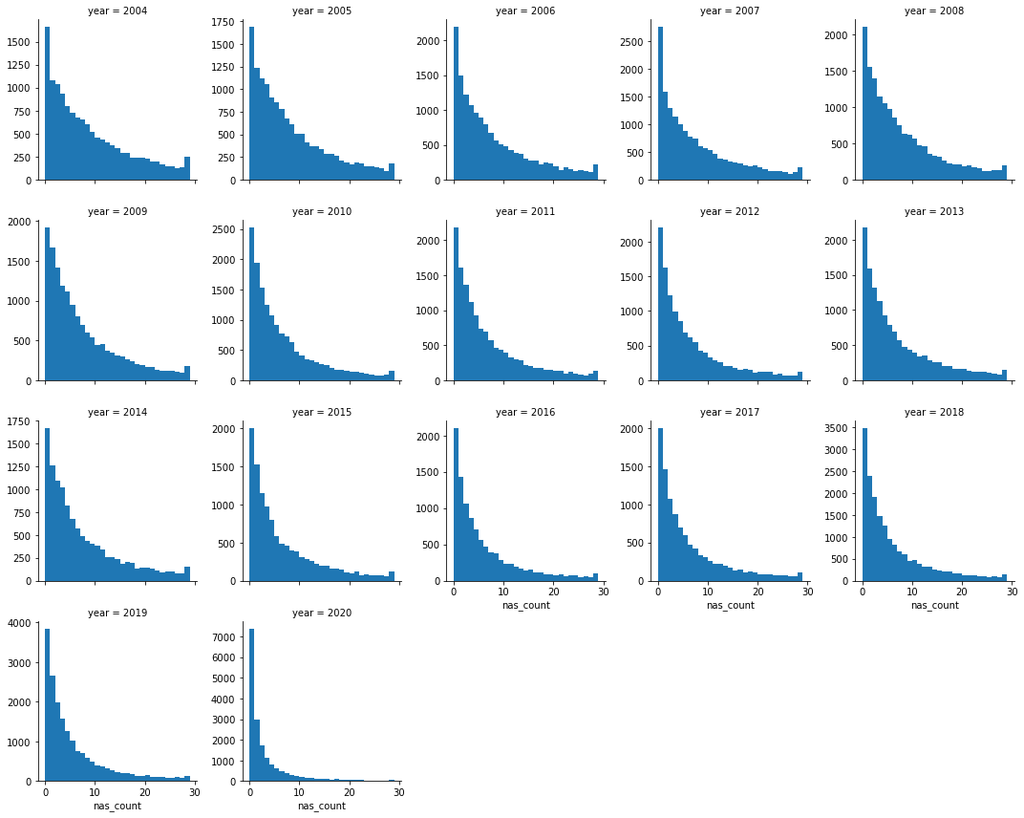

```python
g = sb.FacetGrid(data = df, col = 'year', col_wrap=5, sharey=False)
bins = range(0, 30, 1)
g.map(plt.hist, "nas_count", bins = bins);
```

> The Figure shows the frequency of the number of flights delayed because of the national aviation system in each year

### Relation Between Average Total Delayed Arrival Time (min) And Year

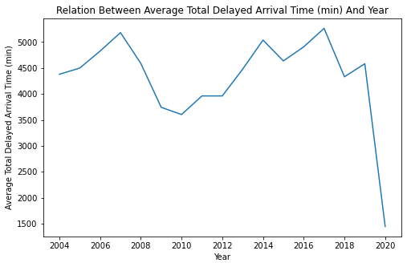

```python
df_year = df.groupby('year')['total_arr_delay_min'].mean().reset_index()
plt.figure(figsize = [8, 5])
base_color = sb.color_palette()[0]
sb.lineplot(data = df_year, x='year', y='total_arr_delay_min', color = base_color)
plt.xlabel("Year")
plt.ylabel("Average Total Delayed Arrival Time (min)")
plt.title("Relation Between Average Total Delayed Arrival Time (min) And Year");
```

### Relation Between Flights Delayed Because Of Carrier And The Total Time Delayed Because Of Carrier

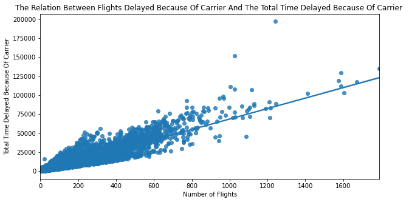

```python
plt.figure(figsize = [10, 5])
sb.regplot(data = df, x = 'carrier_count', y = 'carrier_delay_min')
plt.xlabel("Number of Flights")
plt.ylabel("Total Time Delayed Because Of Carrier")
plt.title("The Relation Between Flights Delayed Because Of Carrier And The Total Time Delayed Because Of Carrier ");
```

> The Figure shows a strong positive relation between the number of flights delayed and the total delayed time, where the delay because of air carrier issue. Which inducates that when the number of flights increase, the delay time increase.

### Relation Between Flights Delayed Because Of Weather And The Total Time Delayed Because Of Weather

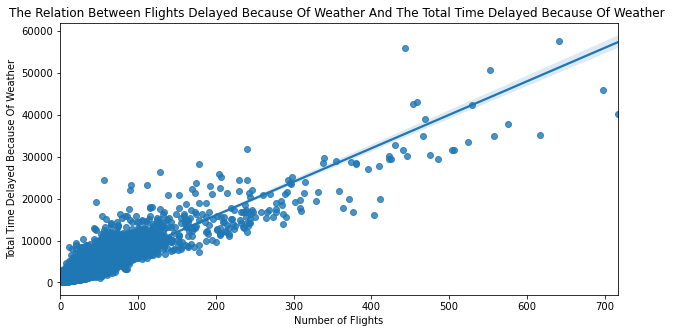

```python
plt.figure(figsize = [10, 5])
sb.regplot(data = df, x = 'weather_count', y = 'weather_delay_min')
plt.xlabel("Number of Flights")
plt.ylabel("Total Time Delayed Because Of Weather")
plt.title("The Relation Between Flights Delayed Because Of Weather And The Total Time Delayed Because Of Weather ");
```

> The Figure shows a positive relation between the number of flights delayed and the total delayed time, where the delay because of weather issue.

### Relation Between Flights Delayed Because Of NAS And The Total Time Delayed Because Of NAS

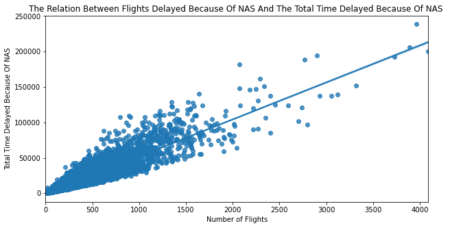

```python
plt.figure(figsize = [10, 5])
sb.regplot(data = df, x = 'nas_count', y = 'nas_delay_min')
plt.xlabel("Number of Flights")
plt.ylabel("Total Time Delayed Because Of NAS")
plt.title("The Relation Between Flights Delayed Because Of NAS And The Total Time Delayed Because Of NAS ");
```

> The Figure shows a positive relation between the number of flights delayed and the total delayed time, where the delay because of national aviation system issue.

### Relation Between Flights Delayed Because Of Security And The Total Time Delayed Because Of Security

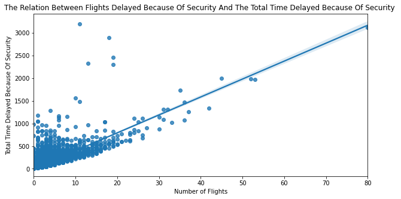

```python
plt.figure(figsize = [10, 5])
sb.regplot(data = df, x = 'security_count', y = 'security_delay_min')
plt.xlabel("Number of Flights")
plt.ylabel("Total Time Delayed Because Of Security")
plt.title("The Relation Between Flights Delayed Because Of Security And The Total Time Delayed Because Of Security ");
```

> The Figure shows a positive relation between the number of flights delayed and the total delayed time, where the delay because of security issue.

### Relation Between Flights Delayed Because Of Late Aircraft And The Total Time Delayed Because Of Late Aircraft

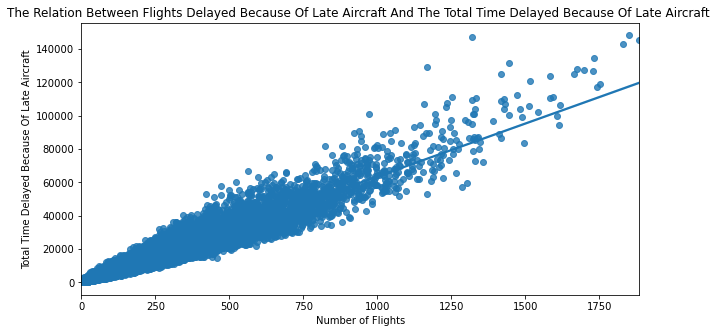

```python
plt.figure(figsize = [10, 5])
sb.regplot(data = df, x = 'late_aircraft_count', y = 'late_aircraft_delay_min')
plt.xlabel("Number of Flights")
plt.ylabel("Total Time Delayed Because Of Late Aircraft")
plt.title("The Relation Between Flights Delayed Because Of Late Aircraft And The Total Time Delayed Because Of Late Aircraft ");
```

> The Figure shows a positive relation between the number of flights delayed and the total delayed time, where the delay because of late aircraft issue.

### Delay Reasons Per Year

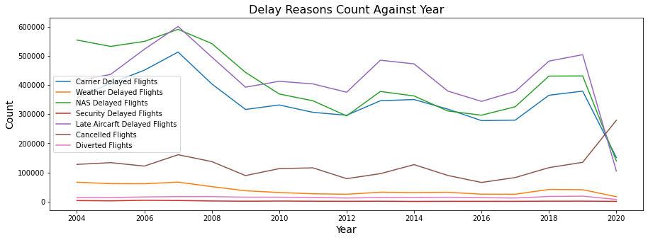

```python
plt.subplots(figsize = (15, 5))

df_reasons = df.groupby('year')['carrier_count'].sum().reset_index()
sb.lineplot(data = df_reasons, x='year', y='carrier_count', label = "Carrier Delayed Flights")

df_reasons = df.groupby('year')['weather_count'].sum().reset_index()
sb.lineplot(data = df_reasons, x='year', y='weather_count', label = "Weather Delayed Flights")

df_reasons = df.groupby('year')['nas_count'].sum().reset_index()
sb.lineplot(data = df_reasons, x='year', y='nas_count', label = "NAS Delayed Flights")

df_reasons = df.groupby('year')['security_count'].sum().reset_index()
sb.lineplot(data = df_reasons, x='year', y='security_count', label = "Security Delayed Flights")

df_reasons = df.groupby('year')['late_aircraft_count'].sum().reset_index()
sb.lineplot(data = df_reasons, x='year', y='late_aircraft_count', label = "Late Aircarft Delayed Flights")

df_reasons = df.groupby('year')['arr_cancelled_count'].sum().reset_index()
sb.lineplot(data = df_reasons, x='year', y='arr_cancelled_count', label = "Cancelled Flights")

df_reasons = df.groupby('year')['arr_diverted_count'].sum().reset_index()
sb.lineplot(data = df_reasons, x='year', y='arr_diverted_count', label = "Diverted Flights")

plt.title('Delay Reasons Count Against Year', fontsize=16)
plt.xlabel('Year', fontsize=14)
plt.ylabel('Count', fontsize=14);
```

> The prevoius figure shows the variation of the delay reasons over the years. It shows that the least delay was because of security issue, and the most delay was because of late aircraft issue. We can notice that the most number of cancelled flights was in 2020 and we can conclude that it was because of the covid 19 pandemic.

### Total Delayed Arrival Time for The Most 100 Frequentied cities

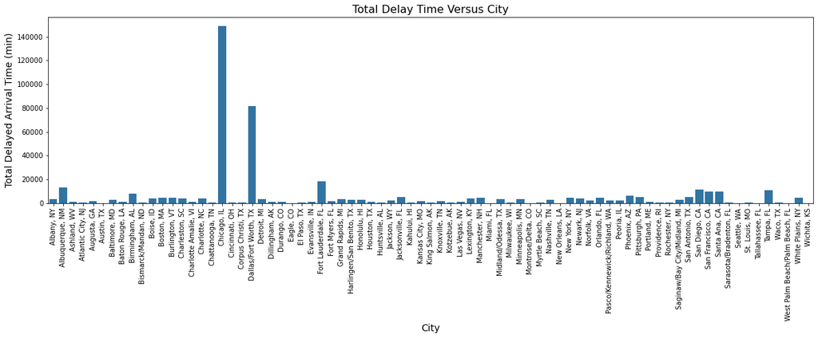

```python
df_cities = df.loc[(df.city_name.value_counts().nlargest(100))]
plt.figure(figsize = [20, 5])
df_cities1 = df_cities.groupby('city_name')['total_arr_delay_min'].sum().reset_index()
base_color = sb.color_palette()[0]
sb.barplot(data = df_cities1, x='city_name', y='total_arr_delay_min', color = base_color)
plt.xticks(rotation=90)
plt.title('Total Delay Time Versus City', fontsize=16)
plt.xlabel('City', fontsize=14)
plt.ylabel('Total Delayed Arrival Time (min)', fontsize=14);
```

> Here we can see the total delayed arrival time for the 100 frequentied cities. Which shows that Chicago has the most delayed time which means the most delayed number of flights. And Dallas city comes in the second position.

### Percentage of Number Of Flights Delayed Of Each Reason Type

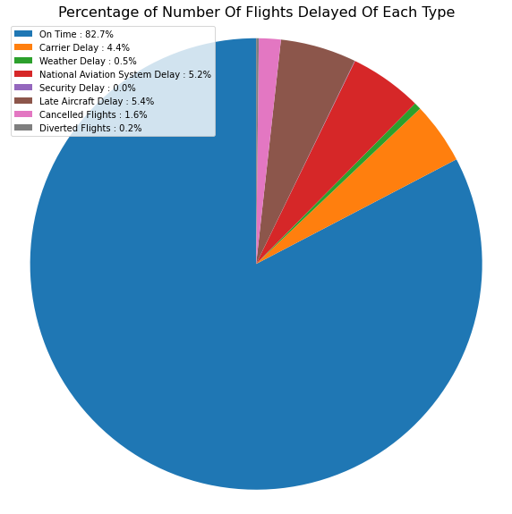

```python
total_no_of_flights = df.arr_flights_on_time.sum() + df.carrier_count.sum() + df.weather_count.sum() + df.nas_count.sum() + df.security_count.sum() + df.late_aircraft_count.sum() + df.arr_cancelled_count.sum() + df.arr_diverted_count.sum()
perc_on_time = (df.arr_flights_on_time.sum() / total_no_of_flights) * 100
perc_carrier = (df.carrier_count.sum() / total_no_of_flights) * 100
perc_weather = (df.weather_count.sum() / total_no_of_flights) * 100
perc_nas = (df.nas_count.sum() / total_no_of_flights) * 100
perc_security = (df.security_count.sum() / total_no_of_flights) * 100
perc_late_aircraft = (df.late_aircraft_count.sum() / total_no_of_flights) * 100
perc_cancelled = (df.arr_cancelled_count.sum() / total_no_of_flights) * 100
perc_diverted = (df.arr_diverted_count.sum() / total_no_of_flights) * 100
#print(perc_on_time, perc_carrier, perc_weather, perc_nas, perc_security, perc_late_aircraft, perc_cancelled, perc_diverted)

plt.figure(figsize = [10, 10])
labels = 'On Time : 82.7%', 'Carrier Delay : 4.4%', 'Weather Delay : 0.5%', 'National Aviation System Delay : 5.2%', 'Security Delay : 0.0%', 'Late Aircraft Delay : 5.4%', 'Cancelled Flights : 1.6%', 'Diverted Flights : 0.2%'
sizes = [perc_on_time, perc_carrier, perc_weather, perc_nas, perc_security, perc_late_aircraft, perc_cancelled, perc_diverted]

plt.pie(sizes, startangle=90)
plt.axis('equal')
plt.legend(labels)
plt.title('Percentage of Number Of Flights Delayed Of Each Type', fontsize=16)
plt.show();
```

> We can see from the pie chart the percent of the number of flights arrived on time and the flights delayed. And it actually approves with the previous line chart which shows that the least number of flights delayed because of security issue, and the most number of flights delayed because of late aircraft.

### Did you observe any interesting relationships between the other features (not the main feature(s) of interest)?

> The total delayed arrival time for the 100 frequentied cities was plotted and it shows that Chicago has the most delayed time which means the most delayed number of flights. And Dallas city comes in the second position.

## Multivariate Exploration

> Create plots of three or more variables to investigate your data even further. Make sure that your investigations are justified, and follow from your work in the previous sections.

### Average Delayed Arrival Time Per Year And Month

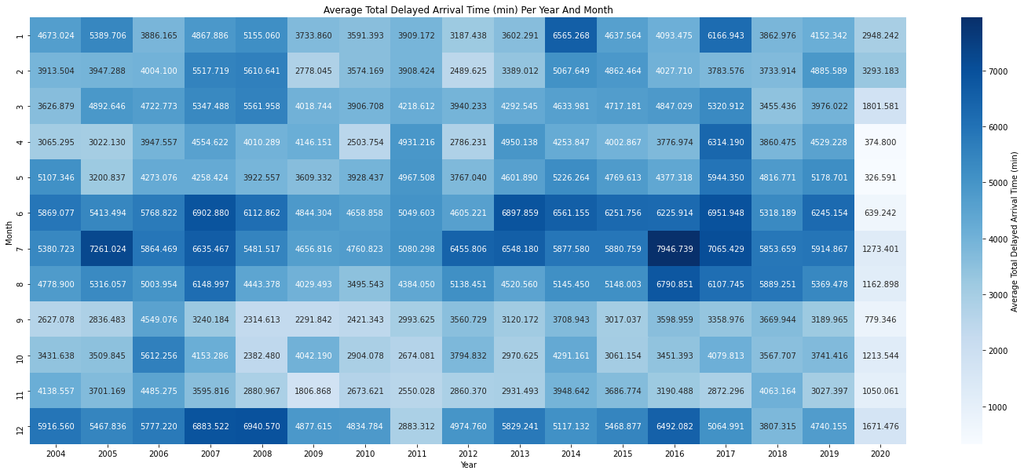

```python
means = df.groupby(['year', 'month'])['total_arr_delay_min'].mean()
means = means.reset_index(name = 'total_arr_delay_min_avg')
means = means.pivot(index = 'month', columns = 'year', values = 'total_arr_delay_min_avg')
plt.figure(figsize = (25, 10))
sb.heatmap(means, annot = True, fmt = '.3f', cbar_kws = {'label' : 'Average Total Delayed Arrival Time (min)'}, cmap="Blues")
plt.xlabel("Year")
plt.ylabel("Month")
plt.title("Average Total Delayed Arrival Time (min) Per Year And Month" );
```

> The previous heat map shows the average total delayed time in both year and month. July 2016 has the highest average delayed time for arrival.

### Number Delayed Flights Per Year And Month

```python
df["total_delayed_flights"] = df["carrier_count"]+ df["weather_count"] + df["nas_count"] + df["security_count"] + df["late_aircraft_count"] + df["arr_cancelled_count"] + df["arr_diverted_count"]
total = df.groupby(['year', 'month'])["total_delayed_flights"].sum()
total = total.reset_index(name = 'total_delayed_flights')
total = total.pivot(index = 'month', columns = 'year', values = 'total_delayed_flights')
plt.figure(figsize = (25, 10))
sb.heatmap(means, annot = True, fmt = '.3f', cbar_kws = {'label' : 'Total Delayed Flights'}, cmap="Blues")
plt.xlabel("Year")
plt.ylabel("Month")
plt.title("Total Delayed Flights Per Year And Month" );
```

[output not shown]

### Talk about some of the relationships you observed in this part of the investigation. Were there features that strengthened each other in terms of looking at your feature(s) of interest?

> At the end of your report, make sure that you export the notebook as an html file from the `File > Download as... > HTML` menu. Make sure you keep track of where the exported file goes, so you can put it in the same folder as this notebook for project submission. Also, make sure you remove all of the quote-formatted guide notes like this one before you finish your report!